# Rcode: COMPSAC 2024

Sulalitha Bowala

```r
rm(list=ls(all=TRUE)) # Remove objects from environment
set.seed(12)
```

```r
### Call packages
require("tseries") # load the tseries library
require("zoo")
require("moments")
require("car")
require("MASS")
require("stats")
require("VGAM")
require("fGarch")
require("quantmod") # To download data alternatively
require("PerformanceAnalytics") # To draw Timeseries graphs
require("scales")
require("PEIP")
require("dplyr")
require("lubridate")
require("tidyverse")
require("gridExtra")
require("gdata")
require("xtable")
require("vioplot")
require("fpp3")
require("readr")
require("tis")
require("tibble")
require("tsibble")
require("stringr")
require("magrittr")
require("fable")
require("Metrics") # rmse()
require("forecast")
```

```r
# Download data
start.date = '2016-01-01' # starting date of stock
end.date = '2018-12-31' # ending date of stock

# Download Google (GOOG) from Yahoo finance
getSymbols("GOOG", src = "yahoo", from = start.date, to = end.date)
```

```
## [1] "GOOG"
```

```r
GOOG <- na.omit(GOOG)
# create date variable
GOOG <- zoo::fortify.zoo(GOOG)
# Rename date variable
GOOG <- GOOG %>% rename("Date" = "Index")
# create tissble object
GOOG <- as_tsibble(GOOG, index = Date) # create tissble object
# Re-index based on trading days (as there are some missing days)
GOOG_stock <- GOOG |>
  mutate(day = row_number()) |>
  update_tsibble(index = day, regular = TRUE)



# Download VIX (^VIX) from Yahoo finance
getSymbols("^VIX", src = "yahoo", from = start.date, to = end.date)
```

```
## [1] "VIX"
```

```r
VIX <- na.omit(VIX)
# create date variable
VIX <- zoo::fortify.zoo(VIX)
# Rename date variable
VIX <- VIX %>% rename("Date" = "Index")
# create tissble object
VIX <- as_tsibble(VIX, index = Date) # create tissble object
# Re-index based on trading days (as there are some missing days)
VIX_stock <- VIX |>
  mutate(day = row_number()) |>
  update_tsibble(index = day, regular = TRUE)


# Download Bitcoin (BTC-USD) from Yahoo finance
BTC <- getSymbols("BTC-USD", from = start.date, to = end.date, source="yahoo", auto.assign=FALSE, return.class="xts")
BTC <- na.omit(BTC)
# create date variable
BTC <- zoo::fortify.zoo(BTC)
# Rename date variable
BTC <- BTC %>% rename("Date" = "Index")
# create tissble object
BTC <- as_tsibble(BTC, index = Date) # create tissble object
# Re-index based on trading days (as there are some missing days)
BTC_stock <- BTC |>
  mutate(day = row_number()) |>
  update_tsibble(index = day, regular = TRUE)
colnames(BTC_stock) <- c("Date","BTC.Open","BTC.High","BTC.Low","BTC.Close","BTC.Volume","BTC.Adjusted","day")
```

```r
## Import data
## Ontario data

Ontario_demand_hourly <- read.csv("Data_2018_2019.csv")
```

```r
### Manipulate hourly data to obtain daily data
### + create a new categorical variable (day-type)

Ontario_demand_hourly$Time <- as.POSIXct(Ontario_demand_hourly$Time, "%Y-%m-%d %H:%M:%S")
```

```r
Ontario_demand_hourly$Temperature <- Ontario_demand_hourly$Temperature
Ontario_demand_hourly$Precipitation <- Ontario_demand_hourly$Precipitation
Ontario_demand_hourly$CloudCover <- Ontario_demand_hourly$CloudCover
Ontario_demand_hourly$IrradianceSurface <- Ontario_demand_hourly$IrradianceSurface
Ontario_demand_hourly$IrradianceToa <- Ontario_demand_hourly$IrradianceToa
Ontario_demand_hourly$Snowfall <- Ontario_demand_hourly$Snowfall
Ontario_demand_hourly$SnowMass <- Ontario_demand_hourly$SnowMass
Ontario_demand_hourly$Location <- Ontario_demand_hourly$Location
Ontario_demand_hourly <- as_tsibble(Ontario_demand_hourly,index = 'Time',key = 'Location')

Ontario_demand_hourly <- Ontario_demand_hourly %>%
  mutate(
    Date = date( Time)
  )
Ontario_demand_hourly <- Ontario_demand_hourly %>%
  mutate(
    Holiday = isHoliday(Ontario_demand_hourly$Date)
  )
Ontario_demand_hourly <- Ontario_demand_hourly %>%
 mutate(Day_Type = case_when(
    Holiday ~ "Holiday",
    wday(Date) %in% 2:6 ~ "Weekday",
    TRUE ~ "Weekend"
  ))
#
head(Ontario_demand_hourly)
```

```
## # A tsibble: 6 x 14 [1h] <%Y-%m-%d %H:%M:%S>
## # Key:       Location [6]
##   Time                Precipitation Temperature IrradianceSurface IrradianceToa
##   <dttm>                      <dbl>       <dbl>             <dbl>         <dbl>
## 1 2018-01-01 00:00:00        0.0099       -16.7                 0             0
## 2 2018-01-01 01:00:00        0.0112       -17.0                 0             0
## 3 2018-01-01 02:00:00        0.0113       -17.2                 0             0
## 4 2018-01-01 03:00:00        0.0125       -17.5                 0             0
## 5 2018-01-01 04:00:00        0.0156       -17.7                 0             0
## 6 2018-01-01 05:00:00        0.0191       -17.7                 0             0
## # ℹ 9 more variables: Snowfall <dbl>, SnowMass <dbl>, CloudCover <dbl>,
## #   AirDensity <dbl>, Demand <int>, Location <int>, Date <date>, Holiday <lgl>,
## #   Day_Type <chr>
```

```r
tail(Ontario_demand_hourly)
```

```
## # A tsibble: 6 x 14 [1h] <%Y-%m-%d %H:%M:%S>
## # Key:       Location [6]
##   Time                Precipitation Temperature IrradianceSurface IrradianceToa
##   <dttm>                      <dbl>       <dbl>             <dbl>         <dbl>
## 1 2019-12-31 18:00:00        0.229       -0.519           99.3         497.
## 2 2019-12-31 19:00:00        0.172       -0.6             74.7         394.
## 3 2019-12-31 20:00:00        0.143       -0.73            45.3         237.
## 4 2019-12-31 21:00:00        0.123       -0.999            9.47         52.2
## 5 2019-12-31 22:00:00        0.0986      -1.26             0.0079        0.0352
## 6 2019-12-31 23:00:00        0.0625      -1.48             0             0
## # ℹ 9 more variables: Snowfall <dbl>, SnowMass <dbl>, CloudCover <dbl>,
## #   AirDensity <dbl>, Demand <int>, Location <int>, Date <date>, Holiday <lgl>,
## #   Day_Type <chr>
```

```r
## Rename columns

Ontario_demand_hourly<-Ontario_demand_hourly[,c("Time","Precipitation","Temperature","IrradianceSurface","IrradianceToa","Snowfall","SnowMass","CloudCover","AirDensity","Demand","Location","Date","Holiday","Day_Type")]
```

```r
## Daily data

# Ontario data
Ontario.Daily <- Ontario_demand_hourly %>%

  index_by(Date = date(Time)) %>%
  summarise(
    Demand = mean(Demand),
    Temperature = mean(Temperature),
    Holiday = any(Holiday),
    Precipitation = mean(Precipitation),
    IrradianceSurface = mean(IrradianceSurface),
    IrradianceToa = mean(IrradianceToa),
    Snowfall = mean(Snowfall),
    SnowMass = mean(SnowMass),
    CloudCover = mean(CloudCover),
    AirDensity = mean(AirDensity),
  ) %>%
  mutate(Day_Type = case_when(
    Holiday ~ "Holiday",
    wday(Date) %in% 2:6 ~ "Weekday",
    TRUE ~ "Weekend"
  ))
Ontario.Daily <- Ontario.Daily %>%
  mutate(Temperature2 = Temperature^2,
         HolidayNew = if_else(Holiday == "TRUE", 1, 0),
         Day_TypeNew = if_else(Day_Type == "Weekday", 1, 0))

head(Ontario.Daily)
```

```
## # A tsibble: 6 x 15 [1D]
##   Date       Demand Temperature Holiday Precipitation IrradianceSurface
##   <date>      <dbl>       <dbl> <lgl>           <dbl>             <dbl>
## 1 2018-01-01 16931.       -14.9 TRUE           0.0216              52.0
## 2 2018-01-02 17953.       -11.4 FALSE          0.0244              41.9
## 3 2018-01-03 18123.       -10.3 FALSE          0.0231              48.7
## 4 2018-01-04 18050.       -11.2 FALSE          0.0263              56.7
## 5 2018-01-05 18961.       -17.6 FALSE          0.0532              42.2
## 6 2018-01-06 18514.       -18.5 FALSE          0.0181              47.7
## # ℹ 9 more variables: IrradianceToa <dbl>, Snowfall <dbl>, SnowMass <dbl>,
## #   CloudCover <dbl>, AirDensity <dbl>, Day_Type <chr>, Temperature2 <dbl>,
## #   HolidayNew <dbl>, Day_TypeNew <dbl>
```

```r
tail(Ontario.Daily)
```

```
## # A tsibble: 6 x 15 [1D]
##   Date       Demand Temperature Holiday Precipitation IrradianceSurface
##   <date>      <dbl>       <dbl> <lgl>           <dbl>             <dbl>
## 1 2019-12-26 14145.      0.462  FALSE         0.0152               22.7
## 2 2019-12-27 14385.      4.19   FALSE         0.0257               65.4
## 3 2019-12-28 14316.      0.0134 FALSE         0.00906              80.0
## 4 2019-12-29 14671.     -0.148  FALSE         0.156                16.9
## 5 2019-12-30 15018.      1.87   FALSE         0.307                59.6
## 6 2019-12-31 14699      -0.362  FALSE         0.183                24.1
## # ℹ 9 more variables: IrradianceToa <dbl>, Snowfall <dbl>, SnowMass <dbl>,
## #   CloudCover <dbl>, AirDensity <dbl>, Day_Type <chr>, Temperature2 <dbl>,
## #   HolidayNew <dbl>, Day_TypeNew <dbl>
```

whether data: https://www.renewables.ninja/

We believe Temperature is affected by other covariates (Precipitation, IrradianceSurface, IrradianceToa, Snowfall, SnowMass, CloudCover, AirDensity) available in the data.

Description of covariates:

Air temperature (°C): Air temperature at 2 meters above ground. T2M variable in MERRA-2, converted from K.

Precipitation (mm / hour): Total bias-corrected precipitation, over land only. PRECTOTLAND variable in MERRA-2, converted from kg m⁻² s⁻¹

Snowfall (mm / hour): Total bias-corrected precipitation in the form of snow, over land only. PRECSNOLAND variable in MERRA-2, converted from kg m⁻² s⁻¹

Snow mass (kg / m²): Amount of snow per land area. SNOMAS variable in MERRA-2, in native units.

Air density (kg / m³): Air density at ground level. RHOA variable in MERRA-2, in native units.

Ground-level solar irradiance (W / m²): Surface-level incident shortwave radiation flux, considering cloud cover and aerosols. SWGDN variable in MERRA-2, in native units. Note, MERRA-2 uses the mean annual climate for aerosols, rather than time-varying quantity.

Top of atmosphere solar irradiance (W / m²): Top of atmosphere incident shortwave radiation flux, before cloud cover and aerosol influences. SWTDN variable in MERRA-2, in native units.

Cloud cover fraction: Fraction of cloud cover, averaged over grid cell and summed over all height above ground. CLDTOT variable in MERRA-2, in native units (a [0, 1] scale).

Check for multicollinearity among selected variables (Precipitation, IrradianceSurface, IrradianceToa, Snowfall, SnowMass, CloudCover, AirDensity).

```r
## VIF (Variance Inflation Factor)

library(car)

model.VIF <- lm(Temperature ~ Precipitation + IrradianceSurface + IrradianceToa + Snowfall + SnowMass + CloudCover + AirDensity, data = Ontario.Daily)

summary(model.VIF)
```

```
##
## Call:
## lm(formula = Temperature ~ Precipitation + IrradianceSurface +
##     IrradianceToa + Snowfall + SnowMass + CloudCover + AirDensity,
##     data = Ontario.Daily)
##
## Residuals:
##     Min      1Q  Median      3Q     Max
## -4.9807 -1.1396 -0.0165  1.1656  4.1187
##
## Coefficients:
##                     Estimate Std. Error t value Pr(>|t|)
## (Intercept)        2.378e+02  2.756e+00  86.309  < 2e-16 ***
## Precipitation     -3.067e+00  7.219e-01  -4.248 2.43e-05 ***
## IrradianceSurface  5.755e-03  2.105e-03   2.734 0.006406 **
## IrradianceToa      1.175e-03  1.410e-03   0.834 0.404721
## Snowfall          -3.654e+00  1.695e+00  -2.156 0.031444 *
## SnowMass          -5.288e-02  1.555e-02  -3.402 0.000707 ***
## CloudCover        -7.400e-01  4.284e-01  -1.727 0.084540 .
## AirDensity        -1.878e+02  2.137e+00 -87.897  < 2e-16 ***
## ---
## Signif. codes:  0 '***' 0.001 '**' 0.01 '*' 0.05 '.' 0.1 ' ' 1
##
## Residual standard error: 1.647 on 722 degrees of freedom
## Multiple R-squared:  0.978,  Adjusted R-squared:  0.9778
## F-statistic:  4588 on 7 and 722 DF,  p-value: < 2.2e-16
```

```r
# Calculate VIF for selected variables
vif_values <- vif(model.VIF)

# Print VIF values
print(vif_values)
```

```
##     Precipitation IrradianceSurface     IrradianceToa          Snowfall
##          1.887588         10.637492          8.480953          1.732499
##          SnowMass        CloudCover        AirDensity
##          2.325717          2.896599          3.594158
```

The Variance Inflation Factor (VIF) is a measure that quantifies how much the variance of an estimated regression coefficient increases if your predictors are correlated. High VIF values (typically > 10) may indicate problematic levels of multicollinearity.

Only for IrradianceSurface we observe a VIF value greater than 10 and VIF of IrradianceToa is close to 10.

```r
## Correlation Matrix

Temp.Ontario.Daily <- Ontario.Daily

colnames(Temp.Ontario.Daily) <- c("Date","Demand","Temperature","Holiday",
                                  "Precipitation","Irradiance (surface)",
                                  "Irradiance (atmosphere)","Snowfall",
                                  "Snow Mass","Cloud Cover","Air Density",
                                  "Day_Type","Temperature2",
                                  "HolidayNew","Day_TypeNew")

# Create a correlation matrix for selected variables
cor_matrix <- cor(Temp.Ontario.Daily[, c("Precipitation", "Irradiance (surface)", "Irradiance (atmosphere)", "Snowfall",  "Snow Mass",  "Cloud Cover", "Air Density")])

# Print the correlation matrix
print(cor_matrix)
```

```
##                         Precipitation Irradiance (surface)
## Precipitation              1.00000000           -0.1867873
## Irradiance (surface)      -0.18678730            1.0000000
## Irradiance (atmosphere)    0.06549682            0.8585024
## Snowfall                   0.43440558           -0.3725886
## Snow Mass                 -0.07238484           -0.5092769
## Cloud Cover                0.39610517           -0.6143980
## Air Density               -0.19473430           -0.6453389
##                         Irradiance (atmosphere)   Snowfall   Snow Mass
## Precipitation                        0.06549682  0.4344056 -0.07238484
## Irradiance (surface)                 0.85850244 -0.3725886 -0.50927687
## Irradiance (atmosphere)              1.00000000 -0.3041690 -0.57578498
## Snowfall                            -0.30416898  1.0000000  0.42130753
## Snow Mass                           -0.57578498  0.4213075  1.00000000
## Cloud Cover                         -0.26407432  0.3135428  0.24889562
## Air Density                         -0.74765953  0.3490269  0.72780921
##                         Cloud Cover Air Density
## Precipitation             0.3961052  -0.1947343
## Irradiance (surface)     -0.6143980  -0.6453389
## Irradiance (atmosphere)  -0.2640743  -0.7476595
## Snowfall                  0.3135428   0.3490269
## Snow Mass                 0.2488956   0.7278092
## Cloud Cover               1.0000000   0.2308716
## Air Density               0.2308716   1.0000000
```

High correlation coefficients (close to 1 or -1) may suggest multicollinearity.

Corr(IrradianceToa, IrradianceSurface) = 0.8585024 Corr(IrradianceSurface, CloudCover) = -0.6143980 Corr(IrradianceSurface, AirDensity) = -0.6453389 Corr(IrradianceToa, AirDensity) = -0.7476595

We can visualize the correlation matrix using tools like corrplot for better insight:

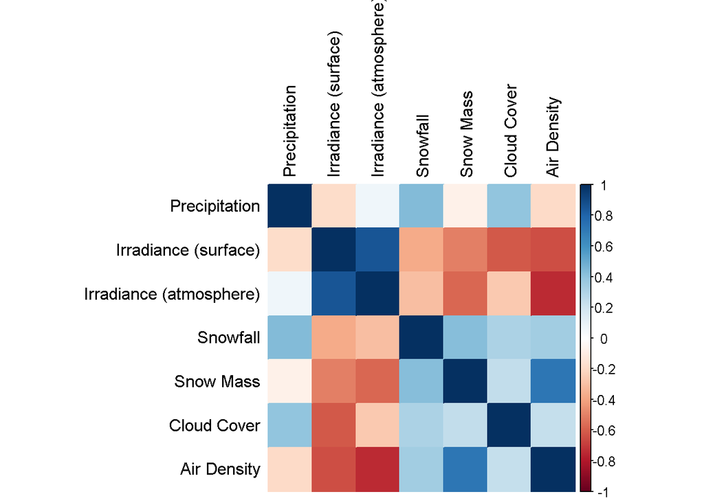

```r
library(corrplot)
# Plot the correlation matrix
corrplot(cor_matrix, method = "color", tl.col="black")
```

Thus, we may omit “IrradianceSurface” and “IrradianceToa” from future models for Temperature to avoid multicollinearity.

## Price forecasts (Google, VIX, BTC) and Temperature forecasts

```r
GOOG.Train <- GOOG_stock

VIX.Train <- VIX_stock

BTC.Train <- BTC_stock

Temp.Train <- Ontario.Daily
```

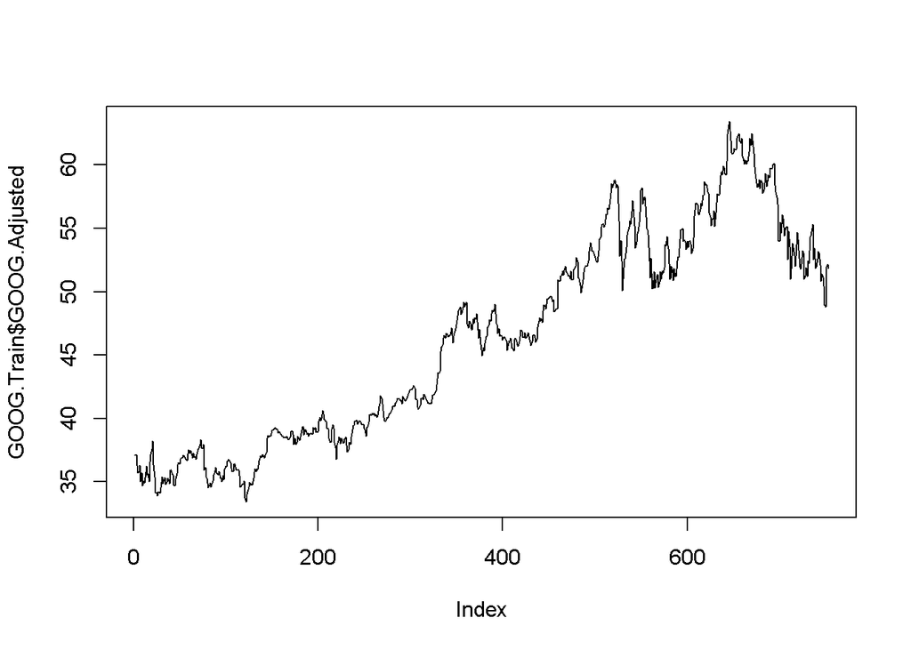

```r
plot(GOOG.Train$GOOG.Adjusted, type = "l")
```

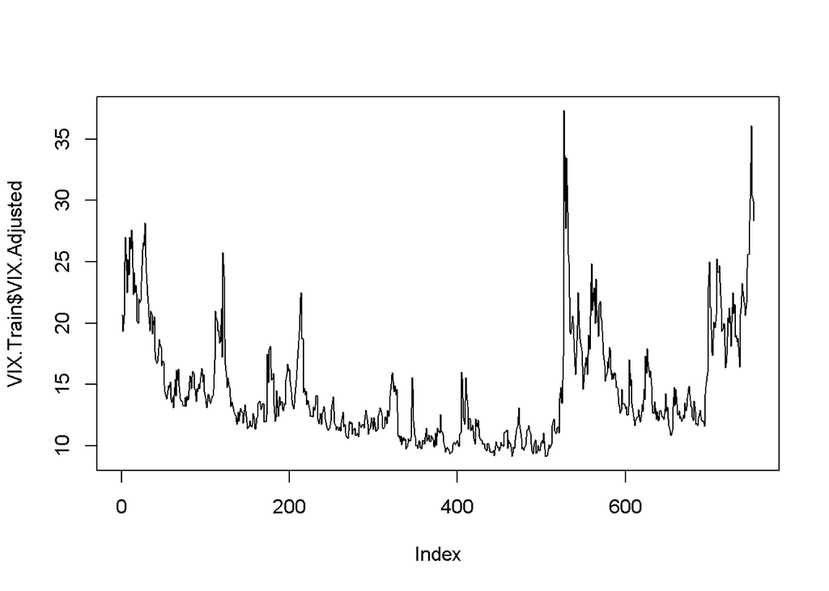

```r
plot(VIX.Train$VIX.Adjusted, type = "l")
```

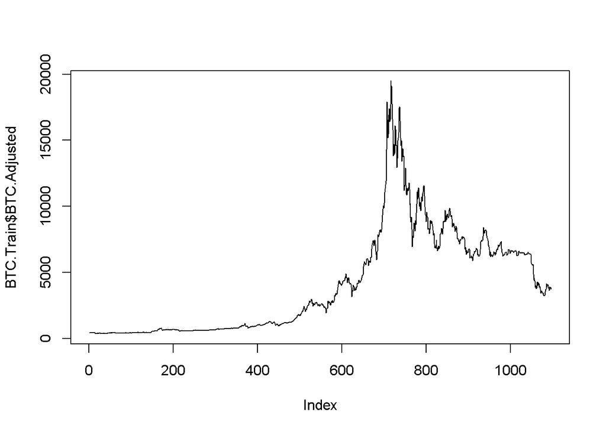

```r
plot(BTC.Train$BTC.Adjusted, type = "l")
```

## Price forecasts (Google)

```r
# Time series cross-validation accuracy (Creating Training dataset)
GOOG.Train.tr <- GOOG.Train |>
  stretch_tsibble(.init = 150, .step = 1) |>
  relocate(Date, .id)
head(GOOG.Train.tr)
```

```
## # A tsibble: 6 x 9 [1]
## # Key:       .id [1]
##   Date         .id GOOG.Open GOOG.High GOOG.Low GOOG.Close GOOG.Volume
##   <date>     <int>     <dbl>     <dbl>    <dbl>      <dbl>       <dbl>
## 1 2016-01-04     1      37.2      37.2     36.6       37.1    65456000
## 2 2016-01-05     1      37.3      37.6     36.9       37.1    39014000
## 3 2016-01-06     1      36.5      37.4     36.4       37.2    38940000
## 4 2016-01-07     1      36.5      36.9     36.0       36.3    59274000
## 5 2016-01-08     1      36.6      36.7     35.7       35.7    49018000
## 6 2016-01-11     1      35.8      35.9     35.2       35.8    41812000
## # ℹ 2 more variables: GOOG.Adjusted <dbl>, day <int>
```

```r
# TSCV accuracy

## Naive model
Naive.Model.GOOG <- GOOG.Train.tr %>%
  model(NAIVE(GOOG.Adjusted))
fore.Naive.GOOG <- Naive.Model.GOOG %>% forecast(h=1)
Naive.GOOG.Accuracy <- fabletools::accuracy(fore.Naive.GOOG, GOOG.Train)
xtable(Naive.GOOG.Accuracy, digits = 4)
```

```
## % latex table generated in R 4.3.2 by xtable 1.8-4 package
## % Sun Feb  4 01:59:18 2024
## \begin{table}[ht]
## \centering
## \begin{tabular}{rllrrrrrrrr}
##   \hline
##  & .model & .type & ME & RMSE & MAE & MPE & MAPE & MASE & RMSSE & ACF1 \\
##   \hline
## 1 & NAIVE(GOOG.Adjusted) & Test & 0.0211 & 0.7052 & 0.4802 & 0.0374 & 0.9566 & 1.0493 & 1.0512 & 0.0186 \\
##    \hline
## \end{tabular}
## \end{table}
```

```r
## Drift model
Drift.Model.GOOG <- GOOG.Train.tr %>%
  model(RW(GOOG.Adjusted~drift()))
fore.Drift.GOOG <- Drift.Model.GOOG %>% forecast(h=1)
Drift.GOOG.Accuracy <- fabletools::accuracy(fore.Drift.GOOG, GOOG.Train)
xtable(Drift.GOOG.Accuracy)
```

```
## % latex table generated in R 4.3.2 by xtable 1.8-4 package
## % Sun Feb  4 01:59:26 2024
## \begin{table}[ht]
## \centering
## \begin{tabular}{rllrrrrrrrr}
##   \hline
##  & .model & .type & ME & RMSE & MAE & MPE & MAPE & MASE & RMSSE & ACF1 \\
##   \hline
## 1 & RW(GOOG.Adjusted \~{} drift()) & Test & -0.00 & 0.71 & 0.48 & -0.01 & 0.96 & 1.05 & 1.05 & 0.02 \\
##    \hline
## \end{tabular}
## \end{table}
```

```r
## Prophet model
library(fable.prophet)
Prophet.Model.GOOG <- GOOG.Train.tr %>%
  model(prophet(GOOG.Adjusted))
fore.Prophet.GOOG <- Prophet.Model.GOOG %>% forecast(h=1)
Prophet.GOOG.Accuracy <- fabletools::accuracy(fore.Prophet.GOOG, GOOG.Train)
xtable(Prophet.GOOG.Accuracy)
```

```
## % latex table generated in R 4.3.2 by xtable 1.8-4 package
## % Sun Feb  4 02:28:22 2024
## \begin{table}[ht]
## \centering
## \begin{tabular}{rllrrrrrrrr}
##   \hline
##  & .model & .type & ME & RMSE & MAE & MPE & MAPE & MASE & RMSSE & ACF1 \\
##   \hline
## 1 & prophet(GOOG.Adjusted) & Test & -0.46 & 2.67 & 2.01 & -1.00 & 3.96 & 4.40 & 3.98 & 0.96 \\
##    \hline
## \end{tabular}
## \end{table}
```

```r
## ARIMA model
ARIMA.Model.GOOG <- GOOG.Train.tr %>%
  model(ARIMA(GOOG.Adjusted))
#ARIMA.Model.GOOG
fore.ARIMA.GOOG <- ARIMA.Model.GOOG %>% forecast(h=1)
ARIMA.GOOG.Accuracy <- fabletools::accuracy(fore.ARIMA.GOOG, GOOG.Train)
xtable(ARIMA.GOOG.Accuracy)
```

```
## % latex table generated in R 4.3.2 by xtable 1.8-4 package
## % Sun Feb  4 02:29:06 2024
## \begin{table}[ht]
## \centering
## \begin{tabular}{rllrrrrrrrr}
##   \hline
##  & .model & .type & ME & RMSE & MAE & MPE & MAPE & MASE & RMSSE & ACF1 \\
##   \hline
## 1 & ARIMA(GOOG.Adjusted) & Test & 0.02 & 0.72 & 0.49 & 0.04 & 0.98 & 1.07 & 1.07 & -0.00 \\
##    \hline
## \end{tabular}
## \end{table}
```

```r
## ARIMA model for the study period
GOOG.Train %>% model(ARIMA(GOOG.Adjusted))
```

```
## # A mable: 1 x 1
##   `ARIMA(GOOG.Adjusted)`
##                  <model>
## 1         <ARIMA(0,1,0)>
```

```r
## nnetar model
nnetar.Model.GOOG <- GOOG.Train.tr %>%
  model(NNETAR(GOOG.Adjusted))
#nnetar.Model.GOOG
fore.nnetar.GOOG <- nnetar.Model.GOOG %>% forecast(h=1)
nnetar.GOOG.Accuracy <- fabletools::accuracy(fore.nnetar.GOOG, GOOG.Train)
xtable(nnetar.GOOG.Accuracy)
```

```
## % latex table generated in R 4.3.2 by xtable 1.8-4 package
## % Sun Feb  4 12:13:20 2024
## \begin{table}[ht]
## \centering
## \begin{tabular}{rllrrrrrrrr}
##   \hline
##  & .model & .type & ME & RMSE & MAE & MPE & MAPE & MASE & RMSSE & ACF1 \\
##   \hline
## 1 & NNETAR(GOOG.Adjusted) & Test & 0.11 & 0.72 & 0.51 & 0.20 & 1.01 & 1.11 & 1.07 & 0.01 \\
##    \hline
## \end{tabular}
## \end{table}
```

```r
## nnetar model for the study period
GOOG.Train %>% model(NNETAR(GOOG.Adjusted))
```

```
## # A mable: 1 x 1
##   `NNETAR(GOOG.Adjusted)`
##                   <model>
## 1             <NNAR(9,5)>
```

```r
## EWMA model
EWMA.Model.GOOG <- GOOG.Train.tr %>%
  model(ETS(GOOG.Adjusted))
fore.EWMA.GOOG <- EWMA.Model.GOOG %>% forecast(h=1)
EWMA.GOOG.Accuracy <- fabletools::accuracy(fore.EWMA.GOOG, GOOG.Train)
xtable(EWMA.GOOG.Accuracy)
```

```
## % latex table generated in R 4.3.2 by xtable 1.8-4 package
## % Sun Feb  4 12:14:01 2024
## \begin{table}[ht]
## \centering
## \begin{tabular}{rllrrrrrrrr}
##   \hline
##  & .model & .type & ME & RMSE & MAE & MPE & MAPE & MASE & RMSSE & ACF1 \\
##   \hline
## 1 & ETS(GOOG.Adjusted) & Test & 0.02 & 0.71 & 0.48 & 0.04 & 0.96 & 1.05 & 1.05 & 0.02 \\
##    \hline
## \end{tabular}
## \end{table}
```

## Price forecasts (VIX)

```r
# Time series cross-validation accuracy (Creating Training dataset)
VIX.Train.tr <- VIX.Train |>
  stretch_tsibble(.init = 150, .step = 1) |>
  relocate(Date, .id)
head(VIX.Train.tr)
```

```
## # A tsibble: 6 x 9 [1]
## # Key:       .id [1]
##   Date         .id VIX.Open VIX.High VIX.Low VIX.Close VIX.Volume VIX.Adjusted
##   <date>     <int>    <dbl>    <dbl>   <dbl>     <dbl>      <dbl>        <dbl>
## 1 2016-01-04     1     22.5     23.4    20.7      20.7          0         20.7
## 2 2016-01-05     1     20.8     21.1    19.2      19.3          0         19.3
## 3 2016-01-06     1     21.7     21.9    19.8      20.6          0         20.6
## 4 2016-01-07     1     23.2     25.9    22.4      25.0          0         25.0
## 5 2016-01-08     1     23.0     27.1    22.5      27.0          0         27.0
## 6 2016-01-11     1     25.6     27.4    23.8      24.3          0         24.3
## # ℹ 1 more variable: day <int>
```

```r
# TSCV accuracy

## Naive model
Naive.Model.VIX <- VIX.Train.tr %>%
  model(NAIVE(VIX.Adjusted))
fore.Naive.VIX <- Naive.Model.VIX %>% forecast(h=1)
Naive.VIX.Accuracy <- fabletools::accuracy(fore.Naive.VIX, VIX.Train)
xtable(Naive.VIX.Accuracy)
```

```
## % latex table generated in R 4.3.2 by xtable 1.8-4 package
## % Sun Feb  4 12:14:08 2024
## \begin{table}[ht]
## \centering
## \begin{tabular}{rllrrrrrrrr}
##   \hline
##  & .model & .type & ME & RMSE & MAE & MPE & MAPE & MASE & RMSSE & ACF1 \\
##   \hline
## 1 & NAIVE(VIX.Adjusted) & Test & 0.03 & 1.55 & 0.85 & -0.19 & 5.46 & 0.96 & 1.00 & -0.09 \\
##    \hline
## \end{tabular}
## \end{table}
```

```r
## Drift model
Drift.Model.VIX <- VIX.Train.tr %>%
  model(RW(VIX.Adjusted~drift()))
fore.Drift.VIX <- Drift.Model.VIX %>% forecast(h=1)
Drift.VIX.Accuracy <- fabletools::accuracy(fore.Drift.VIX, VIX.Train)
xtable(Drift.VIX.Accuracy)
```

```
## % latex table generated in R 4.3.2 by xtable 1.8-4 package
## % Sun Feb  4 12:14:16 2024
## \begin{table}[ht]
## \centering
## \begin{tabular}{rllrrrrrrrr}
##   \hline
##  & .model & .type & ME & RMSE & MAE & MPE & MAPE & MASE & RMSSE & ACF1 \\
##   \hline
## 1 & RW(VIX.Adjusted \~{} drift()) & Test & 0.05 & 1.56 & 0.85 & -0.02 & 5.46 & 0.96 & 1.01 & -0.09 \\
##    \hline
## \end{tabular}
## \end{table}
```

```r
## Prophet model
#library(fable.prophet)
Prophet.Model.VIX <- VIX.Train.tr %>%
  model(prophet(VIX.Adjusted))
fore.Prophet.VIX <- Prophet.Model.VIX %>% forecast(h=1)
Prophet.VIX.Accuracy <- fabletools::accuracy(fore.Prophet.VIX, VIX.Train)
xtable(Prophet.VIX.Accuracy)
```

```
## % latex table generated in R 4.3.2 by xtable 1.8-4 package
## % Sun Feb  4 12:42:20 2024
## \begin{table}[ht]
## \centering
## \begin{tabular}{rllrrrrrrrr}
##   \hline
##  & .model & .type & ME & RMSE & MAE & MPE & MAPE & MASE & RMSSE & ACF1 \\
##   \hline
## 1 & prophet(VIX.Adjusted) & Test & 0.43 & 3.70 & 2.33 & -0.45 & 14.65 & 2.62 & 2.39 & 0.90 \\
##    \hline
## \end{tabular}
## \end{table}
```

```r
## ARIMA model
ARIMA.Model.VIX <- VIX.Train.tr %>%
  model(ARIMA(VIX.Adjusted))
```

[output not shown]

```r
#ARIMA.Model.VIX
fore.ARIMA.VIX <- ARIMA.Model.VIX %>% forecast(h=1)
ARIMA.VIX.Accuracy <- fabletools::accuracy(fore.ARIMA.VIX, VIX.Train)
xtable(ARIMA.VIX.Accuracy)
```

```
## % latex table generated in R 4.3.2 by xtable 1.8-4 package
## % Sun Feb  4 12:44:40 2024
## \begin{table}[ht]
## \centering
## \begin{tabular}{rllrrrrrrrr}
##   \hline
##  & .model & .type & ME & RMSE & MAE & MPE & MAPE & MASE & RMSSE & ACF1 \\
##   \hline
## 1 & ARIMA(VIX.Adjusted) & Test & 0.05 & 1.59 & 0.87 & -0.18 & 5.55 & 0.98 & 1.02 & -0.03 \\
##    \hline
## \end{tabular}
## \end{table}
```

```r
## ARIMA model for the study period
VIX.Train %>% model(ARIMA(VIX.Adjusted))
```

```
## # A mable: 1 x 1
##   `ARIMA(VIX.Adjusted)`
##                 <model>
## 1        <ARIMA(2,1,1)>
```

```r
## nnetar model
nnetar.Model.VIX <- VIX.Train.tr %>%
  model(NNETAR(VIX.Adjusted))
#nnetar.Model.VIX
fore.nnetar.VIX <- nnetar.Model.VIX %>% forecast(h=1)
nnetar.VIX.Accuracy <- fabletools::accuracy(fore.nnetar.VIX, VIX.Train)
xtable(nnetar.VIX.Accuracy)
```

```
## % latex table generated in R 4.3.2 by xtable 1.8-4 package
## % Sun Feb  4 19:14:58 2024
## \begin{table}[ht]
## \centering
## \begin{tabular}{rllrrrrrrrr}
##   \hline
##  & .model & .type & ME & RMSE & MAE & MPE & MAPE & MASE & RMSSE & ACF1 \\
##   \hline
## 1 & NNETAR(VIX.Adjusted) & Test & 0.01 & 1.62 & 0.88 & -0.82 & 5.69 & 0.99 & 1.04 & 0.09 \\
##    \hline
## \end{tabular}
## \end{table}
```

```r
## nnetar model for the study period
VIX.Train %>% model(NNETAR(VIX.Adjusted))
```

```
## # A mable: 1 x 1
##   `NNETAR(VIX.Adjusted)`
##                  <model>
## 1            <NNAR(5,3)>
```

```r
## EWMA model
EWMA.Model.VIX <- VIX.Train.tr %>%
  model(ETS(VIX.Adjusted))
fore.EWMA.VIX <- EWMA.Model.VIX %>% forecast(h=1)
EWMA.VIX.Accuracy <- fabletools::accuracy(fore.EWMA.VIX, VIX.Train)
xtable(EWMA.VIX.Accuracy)
```

```
## % latex table generated in R 4.3.2 by xtable 1.8-4 package
## % Sun Feb  4 19:15:40 2024
## \begin{table}[ht]
## \centering
## \begin{tabular}{rllrrrrrrrr}
##   \hline
##  & .model & .type & ME & RMSE & MAE & MPE & MAPE & MASE & RMSSE & ACF1 \\
##   \hline
## 1 & ETS(VIX.Adjusted) & Test & 0.03 & 1.56 & 0.86 & -0.20 & 5.49 & 0.96 & 1.01 & -0.07 \\
##    \hline
## \end{tabular}
## \end{table}
```

## Price forecasts (BTC)

```r
# Time series cross-validation accuracy (Creating Training dataset)
BTC.Train.tr <- BTC.Train |>
  stretch_tsibble(.init = 220, .step = 1) |>
  relocate(Date, .id)
head(BTC.Train.tr)
```

```
## # A tsibble: 6 x 9 [1]
## # Key:       .id [1]
##   Date         .id BTC.Open BTC.High BTC.Low BTC.Close BTC.Volume BTC.Adjusted
##   <date>     <int>    <dbl>    <dbl>   <dbl>     <dbl>      <dbl>        <dbl>
## 1 2016-01-01     1     431.     436.    428.      434.   36278900         434.
## 2 2016-01-02     1     435.     436.    432.      433.   30096600         433.
## 3 2016-01-03     1     434.     434.    425.      430.   39633800         430.
## 4 2016-01-04     1     430.     435.    429.      433.   38477500         433.
## 5 2016-01-05     1     433.     434.    430.      432.   34522600         432.
## 6 2016-01-06     1     432.     432.    426.      429.   34042500         429.
## # ℹ 1 more variable: day <int>
```

```r
# TSCV accuracy

## Naive model
Naive.Model.BTC <- BTC.Train.tr %>%
  model(NAIVE(BTC.Adjusted))
fore.Naive.BTC <- Naive.Model.BTC %>% forecast(h=1)
Naive.BTC.Accuracy <- fabletools::accuracy(fore.Naive.BTC, BTC.Train)
xtable(Naive.BTC.Accuracy)
```

```
## % latex table generated in R 4.3.2 by xtable 1.8-4 package
## % Sun Feb  4 19:15:51 2024
## \begin{table}[ht]
## \centering
## \begin{tabular}{rllrrrrrrrr}
##   \hline
##  & .model & .type & ME & RMSE & MAE & MPE & MAPE & MASE & RMSSE & ACF1 \\
##   \hline
## 1 & NAIVE(BTC.Adjusted) & Test & 3.60 & 359.95 & 174.79 & 0.12 & 2.88 & 1.23 & 1.12 & 0.08 \\
##    \hline
## \end{tabular}
## \end{table}
```

```r
## Drift model
Drift.Model.BTC <- BTC.Train.tr %>%
  model(RW(BTC.Adjusted~drift()))
fore.Drift.BTC <- Drift.Model.BTC %>% forecast(h=1)
Drift.BTC.Accuracy <- fabletools::accuracy(fore.Drift.BTC, BTC.Train)
xtable(Drift.BTC.Accuracy)
```

```
## % latex table generated in R 4.3.2 by xtable 1.8-4 package
## % Sun Feb  4 19:16:02 2024
## \begin{table}[ht]
## \centering
## \begin{tabular}{rllrrrrrrrr}
##   \hline
##  & .model & .type & ME & RMSE & MAE & MPE & MAPE & MASE & RMSSE & ACF1 \\
##   \hline
## 1 & RW(BTC.Adjusted \~{} drift()) & Test & -2.31 & 360.17 & 174.41 & -0.00 & 2.87 & 1.23 & 1.12 & 0.08 \\
##    \hline
## \end{tabular}
## \end{table}
```

```r
## Prophet model
#library(fable.prophet)
Prophet.Model.BTC <- BTC.Train.tr %>%
  model(prophet(BTC.Adjusted))
fore.Prophet.BTC <- Prophet.Model.BTC %>% forecast(h=1)
Prophet.BTC.Accuracy <- fabletools::accuracy(fore.Prophet.BTC, BTC.Train)
xtable(Prophet.BTC.Accuracy)
```

```
## % latex table generated in R 4.3.2 by xtable 1.8-4 package
## % Sun Feb  4 19:59:32 2024
## \begin{table}[ht]
## \centering
## \begin{tabular}{rllrrrrrrrr}
##   \hline
##  & .model & .type & ME & RMSE & MAE & MPE & MAPE & MASE & RMSSE & ACF1 \\
##   \hline
## 1 & prophet(BTC.Adjusted) & Test & -168.31 & 2003.26 & 1111.62 & -2.26 & 16.44 & 7.84 & 6.22 & 0.98 \\
##    \hline
## \end{tabular}
## \end{table}
```

```r
## ARIMA model
ARIMA.Model.BTC <- BTC.Train.tr %>%
  model(ARIMA(BTC.Adjusted))
#ARIMA.Model.BTC
fore.ARIMA.BTC <- ARIMA.Model.BTC %>% forecast(h=1)
ARIMA.BTC.Accuracy <- fabletools::accuracy(fore.ARIMA.BTC, BTC.Train)
xtable(ARIMA.BTC.Accuracy)
```

```
## % latex table generated in R 4.3.2 by xtable 1.8-4 package
## % Sun Feb  4 20:00:49 2024
## \begin{table}[ht]
## \centering
## \begin{tabular}{rllrrrrrrrr}
##   \hline
##  & .model & .type & ME & RMSE & MAE & MPE & MAPE & MASE & RMSSE & ACF1 \\
##   \hline
## 1 & ARIMA(BTC.Adjusted) & Test & -6.55 & 399.75 & 185.23 & -0.02 & 2.99 & 1.31 & 1.24 & -0.14 \\
##    \hline
## \end{tabular}
## \end{table}
```

```r
## ARIMA model for the study period
BTC.Train %>% model(ARIMA(BTC.Adjusted))
```

```
## # A mable: 1 x 1
##   `ARIMA(BTC.Adjusted)`
##                 <model>
## 1        <ARIMA(1,1,1)>
```

```r
## nnetar model
nnetar.Model.BTC <- BTC.Train.tr %>%
  model(NNETAR(BTC.Adjusted))
#nnetar.Model.BTC
fore.nnetar.BTC <- nnetar.Model.BTC %>% forecast(h=1)
nnetar.BTC.Accuracy <- fabletools::accuracy(fore.nnetar.BTC, BTC.Train)
xtable(nnetar.BTC.Accuracy)
```

```
## % latex table generated in R 4.3.2 by xtable 1.8-4 package
## % Mon Feb  5 06:09:51 2024
## \begin{table}[ht]
## \centering
## \begin{tabular}{rllrrrrrrrr}
##   \hline
##  & .model & .type & ME & RMSE & MAE & MPE & MAPE & MASE & RMSSE & ACF1 \\
##   \hline
## 1 & NNETAR(BTC.Adjusted) & Test & 8.39 & 593.91 & 249.85 & 0.37 & 3.92 & 1.76 & 1.84 & -0.02 \\
##    \hline
## \end{tabular}
## \end{table}
```

```r
## nnetar model for the study period
BTC.Train %>% model(NNETAR(BTC.Adjusted))
```

```
## # A mable: 1 x 1
##   `NNETAR(BTC.Adjusted)`
##                  <model>
## 1          <NNAR(29,15)>
```

```r
## EWMA model
EWMA.Model.BTC <- BTC.Train.tr %>%
  model(ETS(BTC.Adjusted))
fore.EWMA.BTC <- EWMA.Model.BTC %>% forecast(h=1)
EWMA.BTC.Accuracy <- fabletools::accuracy(fore.EWMA.BTC, BTC.Train)
xtable(EWMA.BTC.Accuracy)
```

```
## % latex table generated in R 4.3.2 by xtable 1.8-4 package
## % Mon Feb  5 06:11:02 2024
## \begin{table}[ht]
## \centering
## \begin{tabular}{rllrrrrrrrr}
##   \hline
##  & .model & .type & ME & RMSE & MAE & MPE & MAPE & MASE & RMSSE & ACF1 \\
##   \hline
## 1 & ETS(BTC.Adjusted) & Test & -2.73 & 363.21 & 175.36 & 0.06 & 2.89 & 1.24 & 1.13 & 0.08 \\
##    \hline
## \end{tabular}
## \end{table}
```

## Temperature forecasts

```r
# Time series cross-validation accuracy (Creating Training dataset)
Temp.Train.tr <- Temp.Train |>
  stretch_tsibble(.init = 150, .step = 1) |>
  relocate(Date, .id)
head(Temp.Train.tr)
```

```
## # A tsibble: 6 x 16 [1D]
## # Key:       .id [1]
##   Date         .id Demand Temperature Holiday Precipitation IrradianceSurface
##   <date>     <int>  <dbl>       <dbl> <lgl>           <dbl>             <dbl>
## 1 2018-01-01     1 16931.       -14.9 TRUE           0.0216              52.0
## 2 2018-01-02     1 17953.       -11.4 FALSE          0.0244              41.9
## 3 2018-01-03     1 18123.       -10.3 FALSE          0.0231              48.7
## 4 2018-01-04     1 18050.       -11.2 FALSE          0.0263              56.7
## 5 2018-01-05     1 18961.       -17.6 FALSE          0.0532              42.2
## 6 2018-01-06     1 18514.       -18.5 FALSE          0.0181              47.7
## # ℹ 9 more variables: IrradianceToa <dbl>, Snowfall <dbl>, SnowMass <dbl>,
## #   CloudCover <dbl>, AirDensity <dbl>, Day_Type <chr>, Temperature2 <dbl>,
## #   HolidayNew <dbl>, Day_TypeNew <dbl>
```

```r
# TSCV accuracy

## Mean model
Mean.Model.Temp <- Temp.Train.tr %>%
  model(MEAN(Temperature))
fore.Mean.Temp <- Mean.Model.Temp %>% forecast(h=1)
Mean.Temp.Accuracy <- fabletools::accuracy(fore.Mean.Temp, Temp.Train)
xtable(Mean.Temp.Accuracy)
```

```
## % latex table generated in R 4.3.2 by xtable 1.8-4 package
## % Mon Feb  5 06:11:08 2024
## \begin{table}[ht]
## \centering
## \begin{tabular}{rllrrrrrrrr}
##   \hline
##  & .model & .type & ME & RMSE & MAE & MPE & MAPE & MASE & RMSSE & ACF1 \\
##   \hline
## 1 & MEAN(Temperature) & Test & 2.28 & 11.66 & 10.28 & 99.03 & 464.04 & 2.81 & 2.42 & 0.97 \\
##    \hline
## \end{tabular}
## \end{table}
```

```r
## Naive model
Naive.Model.Temp <- Temp.Train.tr %>%
  model(NAIVE(Temperature))
fore.Naive.Temp <- Naive.Model.Temp %>% forecast(h=1)
Naive.Temp.Accuracy <- fabletools::accuracy(fore.Naive.Temp, Temp.Train)
xtable(Naive.Temp.Accuracy)
```

```
## % latex table generated in R 4.3.2 by xtable 1.8-4 package
## % Mon Feb  5 06:11:15 2024
## \begin{table}[ht]
## \centering
## \begin{tabular}{rllrrrrrrrr}
##   \hline
##  & .model & .type & ME & RMSE & MAE & MPE & MAPE & MASE & RMSSE & ACF1 \\
##   \hline
## 1 & NAIVE(Temperature) & Test & -0.03 & 2.69 & 2.02 & -32.49 & 139.42 & 0.55 & 0.56 & -0.02 \\
##    \hline
## \end{tabular}
## \end{table}
```

```r
## Seasonal Naive model
SNaive.Model.Temp <- Temp.Train.tr %>%
  model(SNAIVE(Temperature))
fore.SNaive.Temp <- SNaive.Model.Temp %>% forecast(h=1)
SNaive.Temp.Accuracy <- fabletools::accuracy(fore.SNaive.Temp, Temp.Train)
xtable(SNaive.Temp.Accuracy)
```

```
## % latex table generated in R 4.3.2 by xtable 1.8-4 package
## % Mon Feb  5 06:11:22 2024
## \begin{table}[ht]
## \centering
## \begin{tabular}{rllrrrrrrrr}
##   \hline
##  & .model & .type & ME & RMSE & MAE & MPE & MAPE & MASE & RMSSE & ACF1 \\
##   \hline
## 1 & SNAIVE(Temperature) & Test & -0.22 & 4.60 & 3.50 & 11.51 & 250.91 & 0.96 & 0.95 & 0.64 \\
##    \hline
## \end{tabular}
## \end{table}
```

```r
## Drift model
Drift.Model.Temp <- Temp.Train.tr %>%
  model(RW(Temperature~drift()))
fore.Drift.Temp <- Drift.Model.Temp %>% forecast(h=1)
Drift.Temp.Accuracy <- fabletools::accuracy(fore.Drift.Temp, Temp.Train)
xtable(Drift.Temp.Accuracy)
```

```
## % latex table generated in R 4.3.2 by xtable 1.8-4 package
## % Mon Feb  5 06:11:30 2024
## \begin{table}[ht]
## \centering
## \begin{tabular}{rllrrrrrrrr}
##   \hline
##  & .model & .type & ME & RMSE & MAE & MPE & MAPE & MASE & RMSSE & ACF1 \\
##   \hline
## 1 & RW(Temperature \~{} drift()) & Test & -0.11 & 2.70 & 2.02 & -32.56 & 140.19 & 0.55 & 0.56 & -0.02 \\
##    \hline
## \end{tabular}
## \end{table}
```

```r
## Prophet Model (without covariates)
Prophet.Model.Temp1 <- Temp.Train.tr %>%
  model(prophet(Temperature))
fore.Prophet.Temp1 <- Prophet.Model.Temp1 %>% forecast(h=1)
Prophet.Test.Accuracy1 <- fabletools::accuracy(fore.Prophet.Temp1, Temp.Train)
xtable(Prophet.Test.Accuracy1)
```

```
## % latex table generated in R 4.3.2 by xtable 1.8-4 package
## % Mon Feb  5 06:38:47 2024
## \begin{table}[ht]
## \centering
## \begin{tabular}{rllrrrrrrrr}
##   \hline
##  & .model & .type & ME & RMSE & MAE & MPE & MAPE & MASE & RMSSE & ACF1 \\
##   \hline
## 1 & prophet(Temperature) & Test & -0.26 & 3.94 & 3.03 & 58.23 & 207.51 & 0.83 & 0.82 & 0.70 \\
##    \hline
## \end{tabular}
## \end{table}
```

```r
## ARIMA Model (without covariates)
ARIMA.Model.Temp1 <- Temp.Train.tr %>%
  model(ARIMA(Temperature))
#ARIMA.Model.Temp1
fore.ARIMA.Temp1 <- ARIMA.Model.Temp1 %>% forecast(h=1)
ARIMA.Test.Accuracy1 <- fabletools::accuracy(fore.ARIMA.Temp1, Temp.Train)
xtable(ARIMA.Test.Accuracy1)
```

```
## % latex table generated in R 4.3.2 by xtable 1.8-4 package
## % Mon Feb  5 06:42:08 2024
## \begin{table}[ht]
## \centering
## \begin{tabular}{rllrrrrrrrr}
##   \hline
##  & .model & .type & ME & RMSE & MAE & MPE & MAPE & MASE & RMSSE & ACF1 \\
##   \hline
## 1 & ARIMA(Temperature) & Test & -0.15 & 2.56 & 1.92 & -31.54 & 115.59 & 0.52 & 0.53 & -0.02 \\
##    \hline
## \end{tabular}
## \end{table}
```

```r
## ARIMA model for the study period
Temp.Train %>% model(ARIMA(Temperature))
```

```
## # A mable: 1 x 1
##       `ARIMA(Temperature)`
##                    <model>
## 1 <ARIMA(1,1,2)(2,0,0)[7]>
```

```r
## nnetar Model (without covariates)
nnetar.Model.Temp1 <- Temp.Train.tr %>%
  model(NNETAR(Temperature))
nnetar.Model.Temp1
```

```
## # A mable: 581 x 2
## # Key:     .id [581]
##      .id `NNETAR(Temperature)`
##    <int>               <model>
##  1     1      <NNAR(3,1,2)[7]>
##  2     2      <NNAR(3,1,2)[7]>
##  3     3      <NNAR(3,1,2)[7]>
##  4     4      <NNAR(3,1,2)[7]>
##  5     5      <NNAR(3,1,2)[7]>
##  6     6      <NNAR(3,1,2)[7]>
##  7     7      <NNAR(3,1,2)[7]>
##  8     8     <NNAR(14,1,8)[7]>
##  9     9      <NNAR(3,1,2)[7]>
## 10    10      <NNAR(3,1,2)[7]>
## # ℹ 571 more rows
```

```r
fore.nnetar.Temp1 <- nnetar.Model.Temp1 %>% forecast(h=1)
nnetar.Test.Accuracy1 <- fabletools::accuracy(fore.nnetar.Temp1, Temp.Train)
xtable(nnetar.Test.Accuracy1)
```

```
## % latex table generated in R 4.3.2 by xtable 1.8-4 package
## % Mon Feb  5 13:38:27 2024
## \begin{table}[ht]
## \centering
## \begin{tabular}{rllrrrrrrrr}
##   \hline
##  & .model & .type & ME & RMSE & MAE & MPE & MAPE & MASE & RMSSE & ACF1 \\
##   \hline
## 1 & NNETAR(Temperature) & Test & -0.34 & 3.12 & 2.32 & -39.58 & 169.47 & 0.63 & 0.65 & 0.13 \\
##    \hline
## \end{tabular}
## \end{table}
```

```r
## nnetar model for the study period
Temp.Train %>% model(NNETAR(Temperature))
```

```
## # A mable: 1 x 1
##   `NNETAR(Temperature)`
##                 <model>
## 1    <NNAR(27,1,14)[7]>
```

```r
## EWMA model
EWMA.Model.Temp <- Temp.Train.tr %>%
  model(ETS(Temperature))
fore.EWMA.Temp <- EWMA.Model.Temp %>% forecast(h=1)
EWMA.Temp.Accuracy <- fabletools::accuracy(fore.EWMA.Temp, Temp.Train)
xtable(EWMA.Temp.Accuracy)
```

```
## % latex table generated in R 4.3.2 by xtable 1.8-4 package
## % Mon Feb  5 13:41:01 2024
## \begin{table}[ht]
## \centering
## \begin{tabular}{rllrrrrrrrr}
##   \hline
##  & .model & .type & ME & RMSE & MAE & MPE & MAPE & MASE & RMSSE & ACF1 \\
##   \hline
## 1 & ETS(Temperature) & Test & -0.04 & 2.70 & 2.03 & -33.20 & 138.49 & 0.55 & 0.56 & 0.02 \\
##    \hline
## \end{tabular}
## \end{table}
```

```r
## TSLM (without covariates)
TSLM.Model.Temp1 <- Temp.Train.tr %>%
  model(TSLM(Temperature))
fore.TSLM.Temp1 <- TSLM.Model.Temp1 %>% forecast(h=1)
TSLM.Temp.Accuracy1 <- fabletools::accuracy(fore.TSLM.Temp1, Temp.Train)
xtable(TSLM.Temp.Accuracy1)
```

```
## % latex table generated in R 4.3.2 by xtable 1.8-4 package
## % Mon Feb  5 13:41:06 2024
## \begin{table}[ht]
## \centering
## \begin{tabular}{rllrrrrrrrr}
##   \hline
##  & .model & .type & ME & RMSE & MAE & MPE & MAPE & MASE & RMSSE & ACF1 \\
##   \hline
## 1 & TSLM(Temperature) & Test & 2.28 & 11.66 & 10.28 & 99.03 & 464.04 & 2.81 & 2.42 & 0.97 \\
##    \hline
## \end{tabular}
## \end{table}
```